# Basic Analysis with Numeric Regressor

Evian Lin

2020/12/29

This file want to glimpse the data and analyze the explanatory power of the comments and time trend, i.e, how many information about number of peoples supported the proposals can we get from these things.

```r
library(tidyverse)
library(lubridate)
```

只考慮已經結案(成案60天後已達到或未達到附議門檻)，避免附議中提案導致偏誤

```r
completed.df <- readRDS("data/clean/completed_df")

str(completed.df)
```

```
## tibble [37,537 x 9] (S3: tbl_df/tbl/data.frame)
##  $ titles       : chr [1:37537] "車輛定期檢驗方式46年不變，積非成是，檢驗員自由心證！" "車輛定期檢驗方式46年不變，積非成是，檢驗員自由心證！" "車輛定期檢驗方式46年不變，積非成是，檢驗員自由心證！" "車輛定期檢驗方式46年不變，積非成是，檢驗員自由心證！" ...
##  $ dates        : chr [1:37537] "2020-11-04" "2020-11-04" "2020-11-04" "2020-11-04" ...
##  $ supports     : chr [1:37537] "5210" "5210" "5210" "5210" ...
##  $ links        : chr [1:37537] "https://join.gov.tw/idea/detail/b07b3434-5a81-4db1-9956-e42d826595a4" "https://join.gov.tw/idea/detail/b07b3434-5a81-4db1-9956-e42d826595a4" "https://join.gov.tw/idea/detail/b07b3434-5a81-4db1-9956-e42d826595a4" "https://join.gov.tw/idea/detail/b07b3434-5a81-4db1-…
##  $ oriContent   : chr [1:37537] "建議修法以符合民眾所需" "贊成修法\n要現在車遵守46年前的規定 不合理\n46年前汽車還沒有那麼多外裝配件\n現在有那麼多種配件了 明明合法卻要拆來拆去" "天龍國檢驗員都不太認公路總局的公文，真的是太過傲嬌了" "不合時宜的舊法只是擾民，該廢除" ...
##  $ cdate        : chr [1:37537] "2020-12-21 12:57:26" "2020-12-21 00:45:25" "2020-12-18 19:47:41" "2020-12-16 23:41:30" ...
##  $ sideType     : chr [1:37537] "Positive" "Positive" "Positive" "Positive" ...
##  $ agreeCount   : int [1:37537] 0 0 0 0 0 0 0 0 0 0 ...
##  $ disagreeCount: int [1:37537] 0 0 0 0 0 0 0 0 0 0 ...
```

```r
completed.df$supports <- as.numeric(completed.df$supports)
completed.df$agreeCount <- as.numeric(completed.df$agreeCount)
```

將成功與未成功提案合併成closed.df

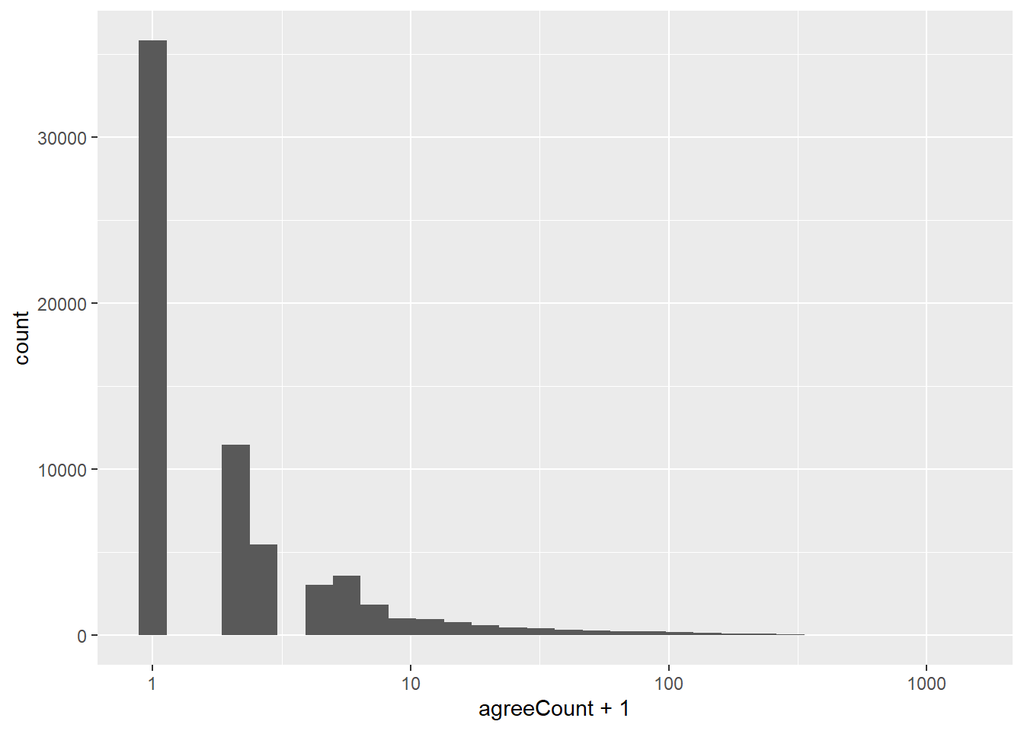

```r
unsuc.df <- readRDS("data/clean/unsuccessed_df")

closed.df <- rbind(unsuc.df, completed.df)
closed.df$supports <- as.numeric(closed.df$supports)
closed.df$agreeCount <- as.numeric(closed.df$agreeCount)

closed.df <- closed.df %>%
    mutate_if(is.numeric, ~replace(., is.na(.), 0))
    #replace NA to 0

closed.df %>%
    mutate(agreeCount = as.numeric(agreeCount)) %>%
    ggplot() + aes(agreeCount+1) +
    geom_histogram() +
    scale_x_log10()
```

```r
#cdate = NA -> 沒有留言
names(closed.df)
```

```
## [1] "titles"        "dates"         "supports"      "links"
## [5] "oriContent"    "cdate"         "sideType"      "agreeCount"
## [9] "disagreeCount"
```

Basic Visualization about Positive and Negative Voices

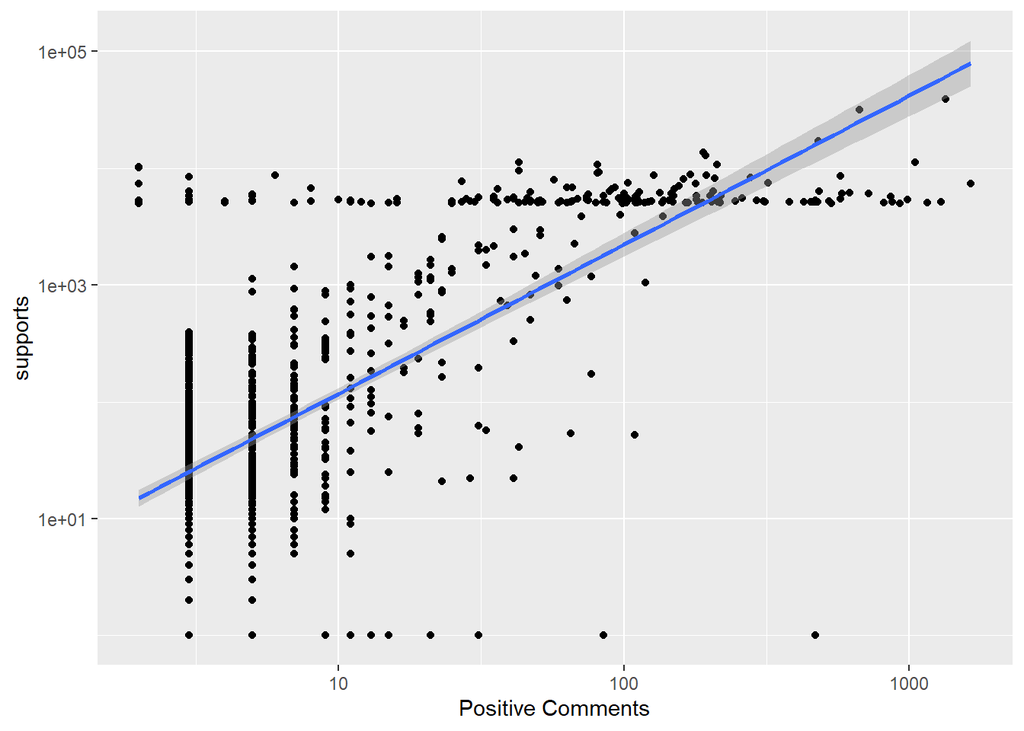

```r
closed.df %>%
    filter(!is.na(sideType)) %>%
    filter(sideType == "Positive") %>%
    group_by(titles) %>%
    add_count() %>%
    ungroup() %>%
    mutate(n = n+1) %>%
    mutate(supports = supports+1) %>%
    #avoid -inf
    distinct(titles, .keep_all = T) %>%
    ggplot() + aes(n, supports) +
    xlab("Positive Comments") +
    scale_x_log10() +
    scale_y_log10() +
    geom_point() +
    geom_smooth(method = "lm")
```

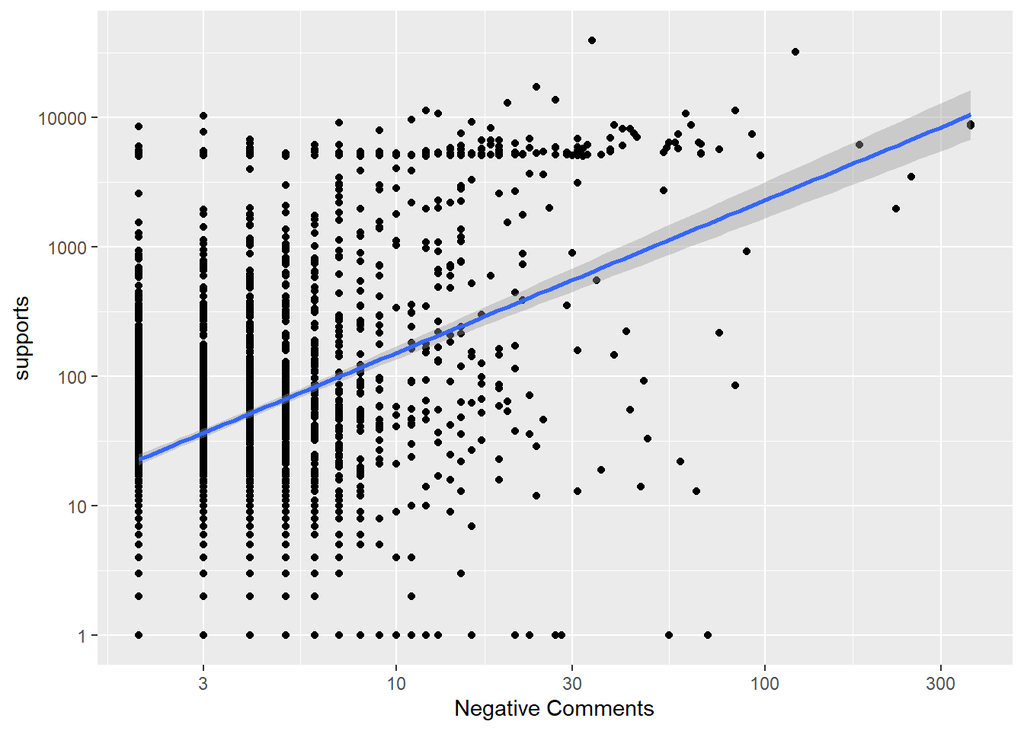

```r
closed.df %>%
    filter(!is.na(sideType)) %>%
    filter(sideType == "Negative") %>%
    group_by(titles) %>%
    add_count() %>%
    ungroup() %>%
    mutate(n = n+1) %>%
    mutate(supports = supports+1) %>%
    #avoid -inf
    distinct(titles, .keep_all = T) %>%
    ggplot() + aes(n, supports) +
    xlab("Negative Comments") +
    scale_x_log10() +
    scale_y_log10() +
    geom_point() +
    geom_smooth(method = "lm")
```

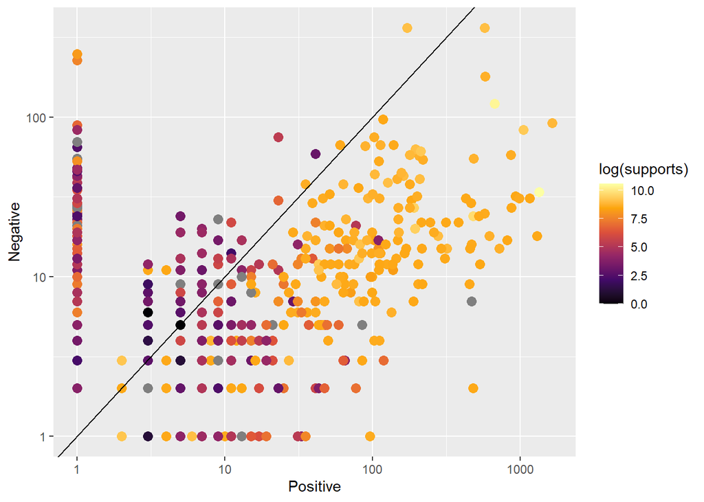

```r
closed.df %>%
    drop_na(sideType) %>%
    #這邊討論留言正負，所以先把沒有留言的drop掉
    group_by(titles,sideType) %>%
    add_count() %>%
    ungroup() %>%
    distinct(titles, sideType, .keep_all = T) %>%
    select(titles,supports, sideType, n) %>%
    spread(key = sideType, value = n) %>%
    mutate_if(is.numeric, ~replace(., is.na(.), 0)) %>%
    mutate(Positive = Positive+1,
           Negative = Negative+1) %>%
    #方便log_scale
    ggplot() + aes(Positive, Negative) +
    scale_x_log10() +
    scale_y_log10() +
    geom_point(aes(color = log(supports)), size = 3) +
    scale_colour_viridis_c(option = "B") +
    geom_abline()
```

```r
#Can try positive/negative or positive-nagitive
```

立場留言中，Positive的正斜率趨勢比較明顯，Negative也稍微有

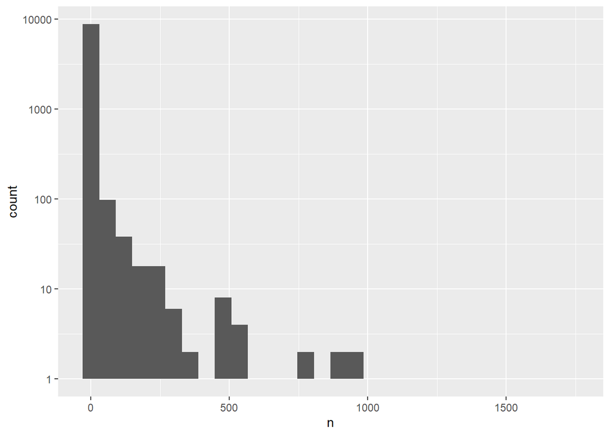

```r
closed.df %>%
    count(titles) %>%
    ggplot() + aes(n) +
    geom_histogram() +
    scale_y_log10()
```

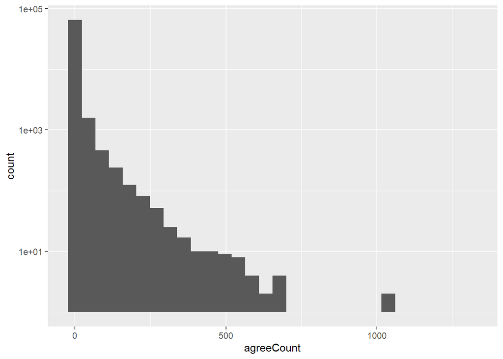

```r
closed.df %>%
    ggplot() + aes(agreeCount) +
    geom_histogram() +
    scale_y_log10()
```

這裡也發現有些如“廢除不公平的教召制度”檢核沒有通過卻沒刪掉

用留言的(讚數+1/倒讚+1)乘以(讚數+倒讚)當作建立argue point做為指標，Negative留言則為乘以(-1) 這個指標可以衡量讚數的比例也考量該留言的曝光度(總聲量)

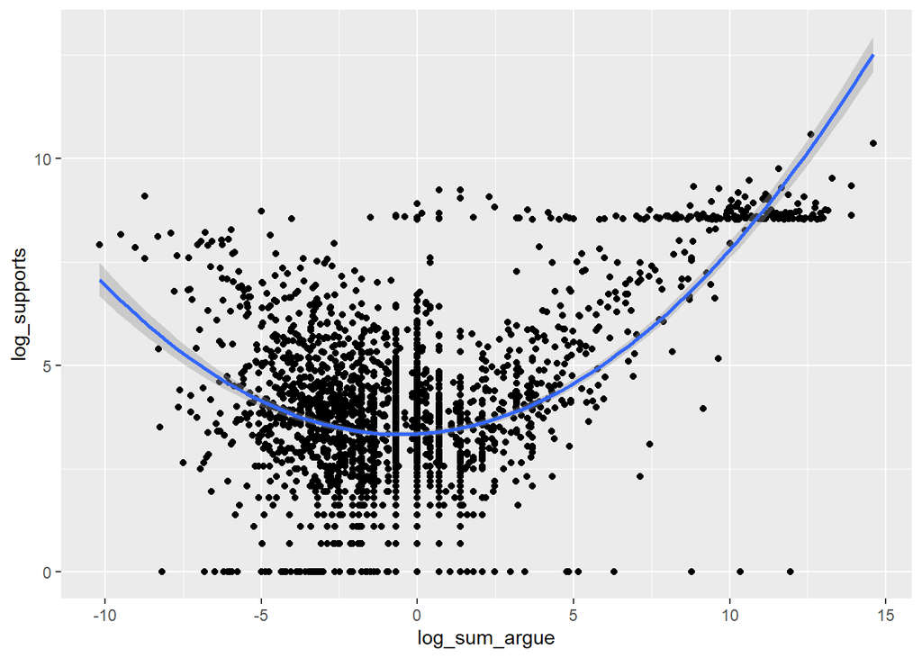

```r
closed.df2 <- closed.df %>%
    filter(!is.na(oriContent)) %>%
    #這邊只論comments故把沒有comments的先filter掉
    mutate(agreeCount = agreeCount+1,
           disagreeCount = disagreeCount+1) %>% #to avoid inf
    mutate(agr_dis_ratio = round(agreeCount/disagreeCount,digits = 3)) %>% #agree/disagree當作該則留言的ratio
    mutate(arguepoint = if_else(sideType == "Positive", agr_dis_ratio*(agreeCount+disagreeCount-2), -agr_dis_ratio*(agreeCount+disagreeCount-2))) %>%
    #這個計算方法下正評增加一的漲幅會相當於直接相減，但是會更重視按讚和倒讚總和(視為該留言影響力)
    #arguepoint為正可能為positive受支持或是negative被反對\
    group_by(titles) %>%
    mutate(sum_argue = sum(arguepoint)) %>%
    ungroup() %>%
    mutate(log_supports = log(supports+1)) %>%
    mutate(argue_sign = case_when(sum_argue>0 ~1, sum_argue ==0 ~0, sum_argue<0 ~(-1))) %>%
    mutate(log_sum_argue = if_else(argue_sign==0, 0,log(abs(sum_argue))*argue_sign))
    #我保留sum_argue的正負號後對其絕對值取log，0的部分則直接為0
closed.df2 %>% distinct(titles, .keep_all = T) %>%
    ggplot() + aes(log_sum_argue, log_supports) +
    geom_point() +
    geom_smooth(method = "lm", formula = y ~ poly(x, 2))
```

```r
closed.df2$log_sum_argue2 <- closed.df2$log_sum_argue^2
Reg <- lm(log_supports ~ log_sum_argue + log_sum_argue2, data = closed.df2)
summary(Reg)
```

```
##
## Call:
## lm(formula = log_supports ~ log_sum_argue + log_sum_argue2, data = closed.df2)
##
## Residuals:
##     Min      1Q  Median      3Q     Max
## -8.9149 -0.6448 -0.0234  0.7832  4.8515
##
## Coefficients:
##                 Estimate Std. Error t value Pr(>|t|)
## (Intercept)    4.3129244  0.0135581  318.11   <2e-16 ***
## log_sum_argue  0.0759572  0.0018459   41.15   <2e-16 ***
## log_sum_argue2 0.0259138  0.0002057  125.99   <2e-16 ***
## ---
## Signif. codes:  0 '***' 0.001 '**' 0.01 '*' 0.05 '.' 0.1 ' ' 1
##
## Residual standard error: 1.457 on 52442 degrees of freedom
## Multiple R-squared:  0.6215, Adjusted R-squared:  0.6215
## F-statistic: 4.305e+04 on 2 and 52442 DF,  p-value: < 2.2e-16
```

正負評似乎影響不大，能拿來預測的似乎只有這則貼文的討論度

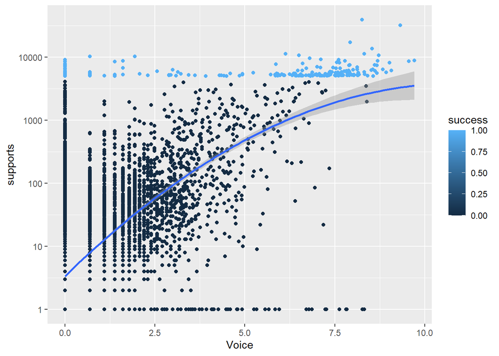

```r
closed.df %>%
    mutate(success = 1*(supports>=5000)) %>%
    mutate(supports = supports+1) %>%
    group_by(titles) %>%
    mutate(Voice = log(sum(agreeCount) + sum(disagreeCount)+1)) %>%
    #把所有留言(無論好壞)的讚和倒讚加起來
    #好像可以用add_count(titles)
    ungroup() %>%
    distinct(titles, .keep_all = T) %>%
    ggplot() + aes(Voice, supports, color = success) +
    scale_y_log10() +
    geom_point() +
    geom_smooth(method = "lm", formula = y ~ poly(x,2))
```

#Closed Cases - Time Trend

```r
closed.df$dates <- as.POSIXct(closed.df$dates)
closed.df$cdate <- as.POSIXct(closed.df$cdate, tz = "Asia/Taipei")
closed.df$cdate <- closed.df$cdate + hours(8)
#發現時間差8個小時，可能是處理時區沒處理好


trend <- lm(closed.df$supports ~ closed.df$dates)
summary(trend)
```

```
##
## Call:
## lm(formula = closed.df$supports ~ closed.df$dates)
##
## Residuals:
##    Min     1Q Median     3Q    Max
##  -4945  -4470    340    991  34466
##
## Coefficients:
##                   Estimate Std. Error t value Pr(>|t|)
## (Intercept)     -2.730e+03  1.121e+03  -2.435   0.0149 *
## closed.df$dates  4.772e-06  7.258e-07   6.575 4.91e-11 ***
## ---
## Signif. codes:  0 '***' 0.001 '**' 0.01 '*' 0.05 '.' 0.1 ' ' 1
##
## Residual standard error: 6712 on 67389 degrees of freedom
## Multiple R-squared:  0.000641,   Adjusted R-squared:  0.0006262
## F-statistic: 43.23 on 1 and 67389 DF,  p-value: 4.911e-11
```

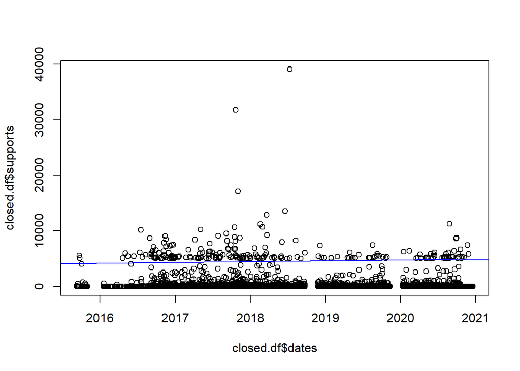

```r
plot(closed.df$dates, closed.df$supports)
abline(reg = trend, col = 'blue')
```

我們可以從圖中判斷此資料分配沒有違反Stationary Hypothesis

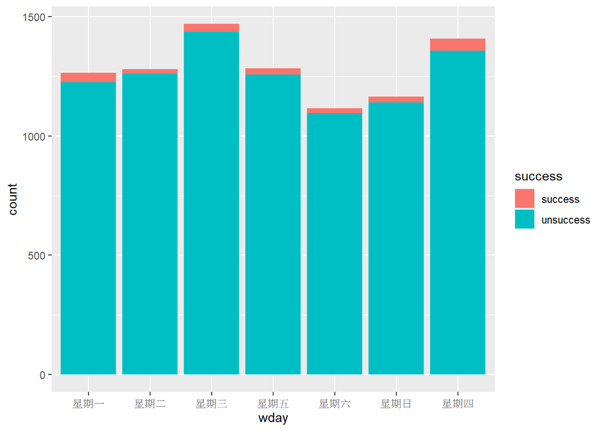

```r
closed.df %>%
    distinct(titles, .keep_all=T) %>%
    mutate(wday = weekdays(dates)) %>%
    mutate(success = if_else(supports>=5000,"success","unsuccess")) %>%
    add_count(wday) %>%
    ggplot() + aes(wday, fill = success) %>%
    geom_bar()
```

這份資料並沒有明顯的受到星期幾影響

接著我想看特定時間段內的留言次數(supports的IV可不可以對於這個議題有很好的預測)

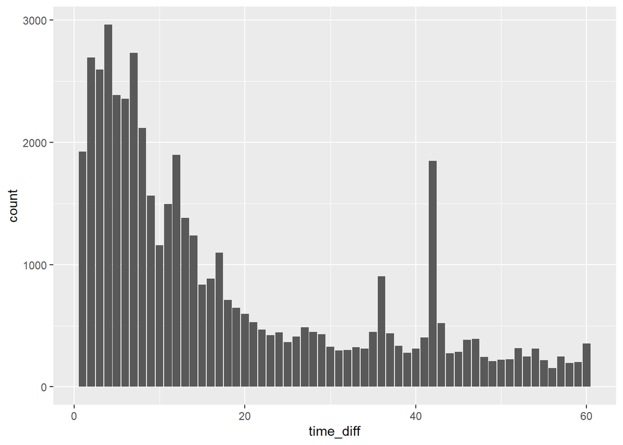

```r
closed.df$dates <- as.POSIXct(closed.df$dates)
closed.df$cdate <- as.POSIXct(closed.df$cdate, tz = "Asia/Taipei")
closed.df$cdate <- closed.df$cdate + hours(8)
closed.with_comments <- closed.df[!is.na(closed.df$cdate),]
closed.with_comments <- closed.with_comments %>%
    mutate(time_diff = floor(difftime(cdate, dates, unit = "days")))
    # distinct(titles, .keep_all = T) %>%
    # count(time_diff > 0) %>%
    #處理完completed.df後仍然有23篇文章的留言時間為負
closed.with_comments %>%
    filter(time_diff>0) %>%
    filter(time_diff<=60) %>%
    #filter掉時間為負的留言，然後先關注60天內的留言，因為附議階段只有60分鐘
    ggplot() + aes(time_diff) +
    geom_bar()
```

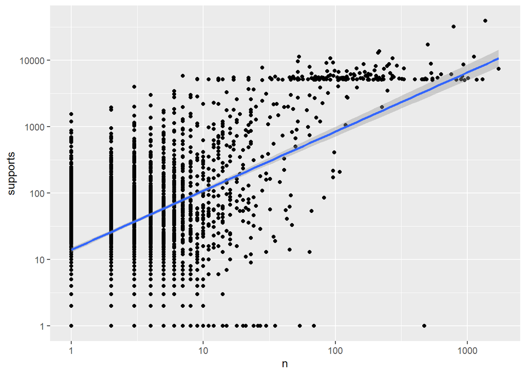

```r
    # + xlim(0,60)


closed.with_comments %>%
    add_count(titles) %>%
    filter(time_diff>0) %>%
    filter(time_diff<=60) %>%
    distinct(titles, .keep_all = T) %>%
    mutate(supports = supports + 1) %>%
    ggplot() + aes(x = n, y = supports) +
    scale_x_log10() +
    scale_y_log10() +
    geom_point() +
    geom_smooth(method = "lm")
```

```r
for (d in c(1,3,7,10,30)){
    reg <- closed.with_comments %>%
    add_count(titles) %>%
    filter(time_diff>0) %>%
    filter(time_diff<= d) %>%
    distinct(titles, .keep_all = T) %>%
    mutate(supports = supports + 1) %>%
    lm(data = ., log(supports) ~ log(n))
    message("in ",d,"days: R2 of log scale = ",summary(reg)$r.squared)
    # summary(reg)$adj.r.squared

    reg2 <- closed.with_comments %>%
    add_count(titles) %>%
    filter(time_diff>0) %>%
    filter(time_diff<= d) %>%
    distinct(titles, .keep_all = T) %>%
    mutate(supports = supports + 1) %>%
    lm(data = ., supports ~ n)
    message("in ",d,"days: R2 = ",summary(reg2)$r.squared)
    # summary(reg)$adj.r.squared
}
```

```
## in 1days: R2 of log scale = 0.459393574866438
```

```
## in 1days: R2 = 0.395008264625512
```

```
## in 3days: R2 of log scale = 0.391063184381584
```

```
## in 3days: R2 = 0.357292707600262
```

```
## in 7days: R2 of log scale = 0.378069855339459
```

```
## in 7days: R2 = 0.436066589935808
```

```
## in 10days: R2 of log scale = 0.360833724544247
```

```
## in 10days: R2 = 0.432563374221078
```

```
## in 30days: R2 of log scale = 0.336265412867998
```

```
## in 30days: R2 = 0.42666920310708
```

```r
# browseURL(test$links[6])
```

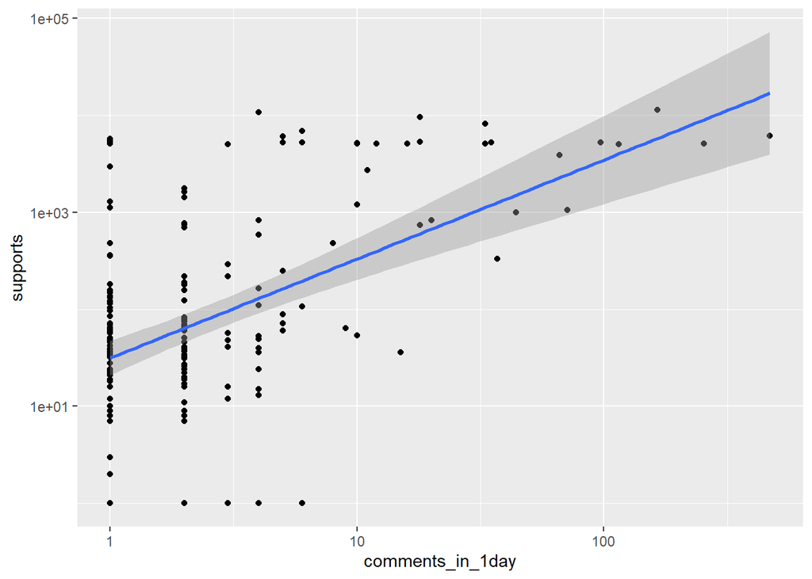

```r
closed.with_comments %>%
    filter(time_diff>0) %>%
    filter(time_diff<= 1) %>%
    group_by(titles) %>%
    add_count() %>%
    rename(comments_in_1day = n) %>%
    ungroup() %>%
    mutate(supports = supports+1) %>%
    distinct(titles, .keep_all = T) %>%
    ggplot() + aes(comments_in_1day, supports)+
    scale_x_log10() +
    scale_y_log10() +
    geom_point() +
    geom_smooth(method = "lm")
```

```r
    #其實不確定這樣的lm是fit y~x還是log(y) ~log(x)

reg <- closed.with_comments %>%
    add_count(titles) %>%
    filter(time_diff>0) %>%
    filter(time_diff<=1) %>%
    distinct(titles, .keep_all = T) %>%
    mutate(supports = supports + 1) %>%
    lm(data = ., log(supports) ~ log(n))

reg$coefficients
```

```
## (Intercept)      log(n)
##    1.978060    1.082646
```

```r
# (log(5001) -2.134119)/1.059550 = 1.476983
# e^1.476983 = 4.379712
```